# FIA - NLS Models: Biomass Growth vs. Stand Age, Temporally-balanced

JAH

2022-10-25

# Background

This document has nls (non-linear least squares) regression fits using the lognormal functional form to USFS FIA (United States Forest Service Forest Inventory & Analysis) **biomass growth vs. stand age** relationships. This functional form is commonly used in growth analyses, and permits a flexible shape to fit to data in an intermediate maximum (i.e., “hump” shaped) relationship. We use the sum of tree biomass growth increment method for the plot biomass growth ($G$) calculation (see supplementary methods). Models are fitted separately by US ecoprovince.

Data have increasing variance in $G$ with increasing $StdAge_{t1}$, Thus, weighted nls is the best approach. We explore a few weighting options and found that proportional weighting can be achieved by weighting observations by $\frac {1} {meanG}$ in equal-sample sized plot biomass bins (n=20) for each ecoprovince.

Model selection is used to determine. to determine the best fitting models, which is implemented in two parts. A first model selection is done to determine the best model form either including $\alpha$: the biomass compensation effect due to lost biomass (natural mortality or harvest), $\phi$: the effect of changing climate (quantified as $\Delta PDSI$, or both. $\Delta PDSI$ is defined the difference in the Palmer drought severity index from January - August for the 10 years preceding the biomass measurement and the 1969-1990 period). We explored $\Delta PDSI$ using only the summer growing months (June-August) over the same intervals, and analyses were insensitive to that change. For the first model selection the following models are considered:

**model 1: simple model** $G = (1 + (yr-1990) \cdot ge/100) \times \left(a + b \cdot \exp{ - \left[ \frac{ \log \left( StdAge_{t1} /c \right)} {d} \right]} ^2 \right)$

**model 2: phi model** $G = (1 + (yr-1990) \cdot ge/100) \times (1 + \phi \cdot \Delta PDSI) \times \left(a + b \cdot \exp{ - \left[ \frac{ \log \left( StdAge_{t1} /c \right)} {d} \right]} ^2 \right)$

**model 3: phi-alpha model** $G = (1 + (yr-1990) \cdot ge/100) \times (1 + \phi \cdot \Delta PDSI) \times (1 - \alpha \cdot B_l) \times \left(a + b \cdot \exp{ - \left[ \frac{ \log \left( StdAge_{t1} /c \right)} {d} \right]} ^2 \right)$

*Note:*

*This analysis only uses plot biomass data from the same plot locations and measurement intervals for which we also have data on biomass growth (which is used in the* **growth vs. biomass analysis** *). We use the second of the two plot measurements comprising a $G$ interval. We further limit this analysis to ‘temporally-balanced’ plot records*

This includes the following plot-based filtering criteria (which were used for the **growth vs. biomass analysis**):

1. exclude FIA plots in plantation forests
2. exclude FIA plots with multiple plot conditions (COND_PROG_UNADJ > 0.95)
3. exclude FIA plots non-productive stands (i.e., those with less than 20 ft^3/acre/year timber producing capability; SITECLCD of 7)
4. exclude FIA plots in non-stocked stands (i.e., those with STDSZCD of 5)
5. exclude FIA plots in non-accessible areas (i.e., private lands etc., COND_STATUS_CD not equal to 1)
6. exclude FIA plot visits that are not part of the annual inventories (which also includes FIA plot visits for Phase 3 ozone measurements)

Additionally, in an effort to clean up the data set, we have removed outlier observations, using a quantile threshold approach. We also calculated plot $G$ using as biomass balance method (see supplementary methods), and the difference between the two methods. Accordingly, we define $diff_G$ as the difference between tree incremental $G$ and biomass balance $G$. We excluded observations which meet the following criteria using a 0.5% quantile ($QT$):

- case A: where the $QT$ difference in tree incremental $G$ is > biomass balance plot G (i.e., > 99.5% $diff_G$ positive outliers)
- case B: where the $QT$ difference in tree incremental $G$ is < mass balance plot G (i.e., < 0.5% $diff_G$ negative outliers)
- case C: where the $QT$ difference in tree incremental $G$ is > 0 (i.e., > 99.5% positive outliers)
- case D: where the $QT$ difference in tree incremental $G$ is > 0 (i.e., < 0.5% negative outliers)

These data set cleaning criteria resulted in the exclusion of 1677 observations.

Below the model fitting procedure is implemented by ecoprovince:

# Temporally-balancing the biomass growth data set

Lets look at some quick attributes of the dataset:

- The data set has 104986 observations, comprised of 55492 plots.
- The frequency of growth measurements among plots is as follows : 25149, 13819, 13897, 2627.
- Thus 54.68 % of plots have at least two growth intervals.

# 211 - Northeastern Mixed Forest

## model selection 1

```
## Error in nls(fg2_1, data = G_211, start = c(ge = ge.start, a = a.start,  :
##   step factor 0.000488281 reduced below 'minFactor' of 0.000976562
## Error in nls(fg2_2, data = G_211, start = c(ge = ge.start, phi = phi.start,  :
##   step factor 0.000488281 reduced below 'minFactor' of 0.000976562
##   model      AIC
## 1     1       NA
## 2     2       NA
## 3     3 17378.73
```

```
##
## Formula: G_obs_TreeInc_MgHaYr ~ (1 + (MEASTIME_avg - 1990) * ge/100) *
##     (1 + phi * DeltaPDSI) * (1 - alpha * B_L_prop) * (a + b *
##     exp(-((log(STDAGE_t1/c))/d)^2))
##
## Parameters:
##         Estimate Std. Error t value Pr(>|t|)
## ge      0.400222   0.184279   2.172   0.0299 *
## phi     0.002586   0.005079   0.509   0.6107
## alpha   0.626488   0.037448  16.730   <2e-16 ***
## a     -50.962941 791.064117  -0.064   0.9486
## b      54.318759 791.051005   0.069   0.9453
## c      27.397549   2.774844   9.874   <2e-16 ***
## d      12.918673  95.353389   0.135   0.8922
## ---
## Signif. codes:  0 '***' 0.001 '**' 0.01 '*' 0.05 '.' 0.1 ' ' 1
##
## Residual standard error: 0.8466 on 4767 degrees of freedom
##
## Number of iterations to convergence: 13
## Achieved convergence tolerance: 2.909e-06
##   (2 observations deleted due to missingness)
```

### summary

- simple model: does not fit
- phi model: does not fit
- phi-alpha model: fits

## plot residuals

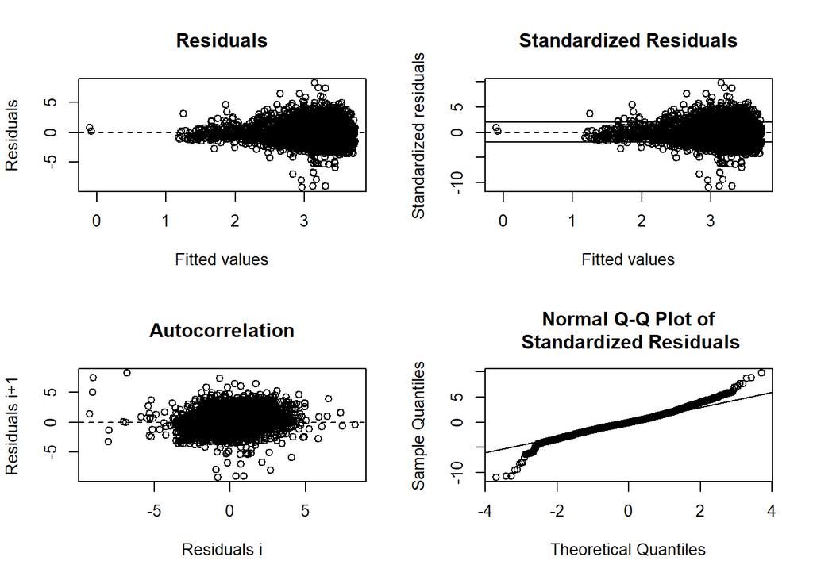

```
##
## ------
##  Shapiro-Wilk normality test
##
## data:  stdres
## W = 0.97784, p-value < 2.2e-16
##
##
## ------
```

```
##
##  Runs Test
##
## data:  as.factor(run)
## Standard Normal = -12.729, p-value < 2.2e-16
## alternative hypothesis: two.sided
```

## predict and plot

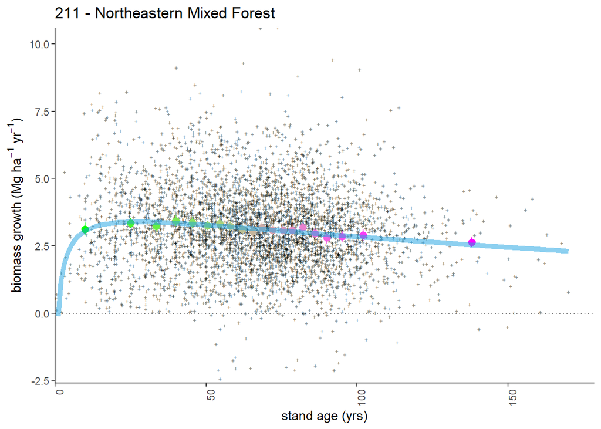

## plotting 2

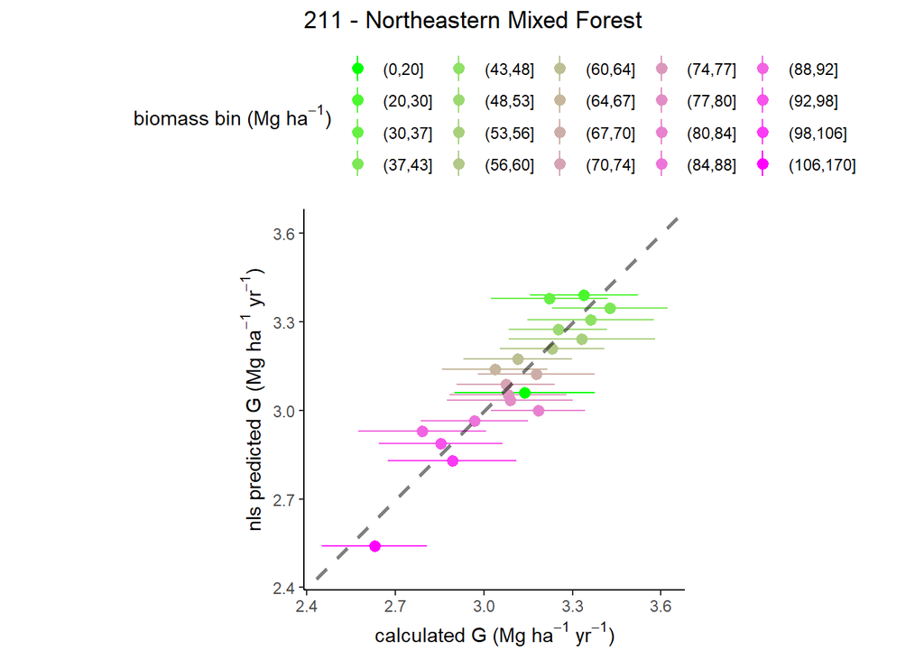

# 212 - Laurentian Mixed Forest

## model selection 1

```
## Analysis of Variance Table
##
## Model 1: G_obs_TreeInc_MgHaYr ~ (1 + (MEASTIME_avg - 1990) * ge/100) * (a + b * exp(-((log(STDAGE_t1/c))/d)^2))
## Model 2: G_obs_TreeInc_MgHaYr ~ (1 + (MEASTIME_avg - 1990) * ge/100) * (1 + phi * DeltaPDSI) * (a + b * exp(-((log(STDAGE_t1/c))/d)^2))
## Model 3: G_obs_TreeInc_MgHaYr ~ (1 + (MEASTIME_avg - 1990) * ge/100) * (1 + phi * DeltaPDSI) * (1 - alpha * B_L_prop) * (a + b * exp(-((log(STDAGE_t1/c))/d)^2))
##   Res.Df Res.Sum Sq Df Sum Sq F value    Pr(>F)
## 1  11662    10018.6
## 2  11659     9971.0  3  47.59  18.548 5.334e-12 ***
## 3  11658     9304.2  1 666.82 835.512 < 2.2e-16 ***
## ---
## Signif. codes:  0 '***' 0.001 '**' 0.01 '*' 0.05 '.' 0.1 ' ' 1
##   model      AIC
## 1     1 41167.55
## 2     2 41108.96
## 3     3 40303.55
```

```
##
## Formula: G_obs_TreeInc_MgHaYr ~ (1 + (MEASTIME_avg - 1990) * ge/100) *
##     (1 + phi * DeltaPDSI) * (1 - alpha * B_L_prop) * (a + b *
##     exp(-((log(STDAGE_t1/c))/d)^2))
##
## Parameters:
##        Estimate Std. Error t value Pr(>|t|)
## ge     0.933189   0.165280   5.646 1.68e-08 ***
## phi    0.029530   0.003848   7.675 1.79e-14 ***
## alpha  0.824610   0.026201  31.472  < 2e-16 ***
## a      0.531233   0.510579   1.040    0.298
## b      2.032581   0.500699   4.059 4.95e-05 ***
## c     19.463757   0.935304  20.810  < 2e-16 ***
## d      2.467958   0.442817   5.573 2.55e-08 ***
## ---
## Signif. codes:  0 '***' 0.001 '**' 0.01 '*' 0.05 '.' 0.1 ' ' 1
##
## Residual standard error: 0.8934 on 11658 degrees of freedom
##
## Number of iterations to convergence: 8
## Achieved convergence tolerance: 9.752e-06
##   (23 observations deleted due to missingness)
```

### summary

- simple model: fits
- phi model: fits
- phi-alpha model: fits

## plot residuals

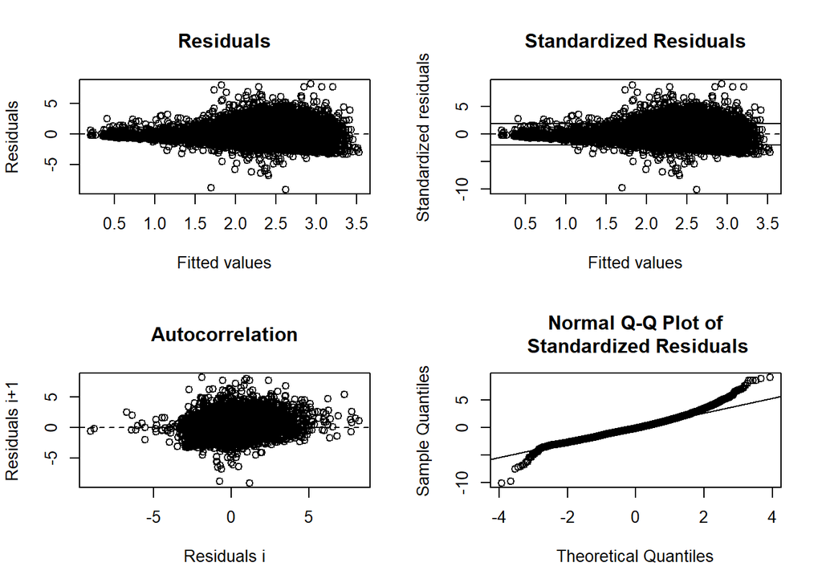

## predict and plot

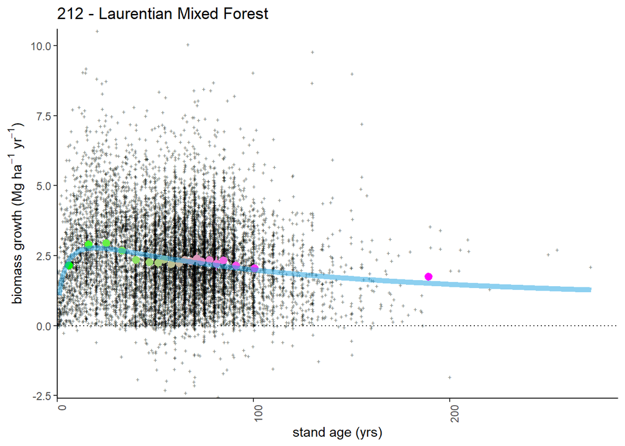

## plotting 2

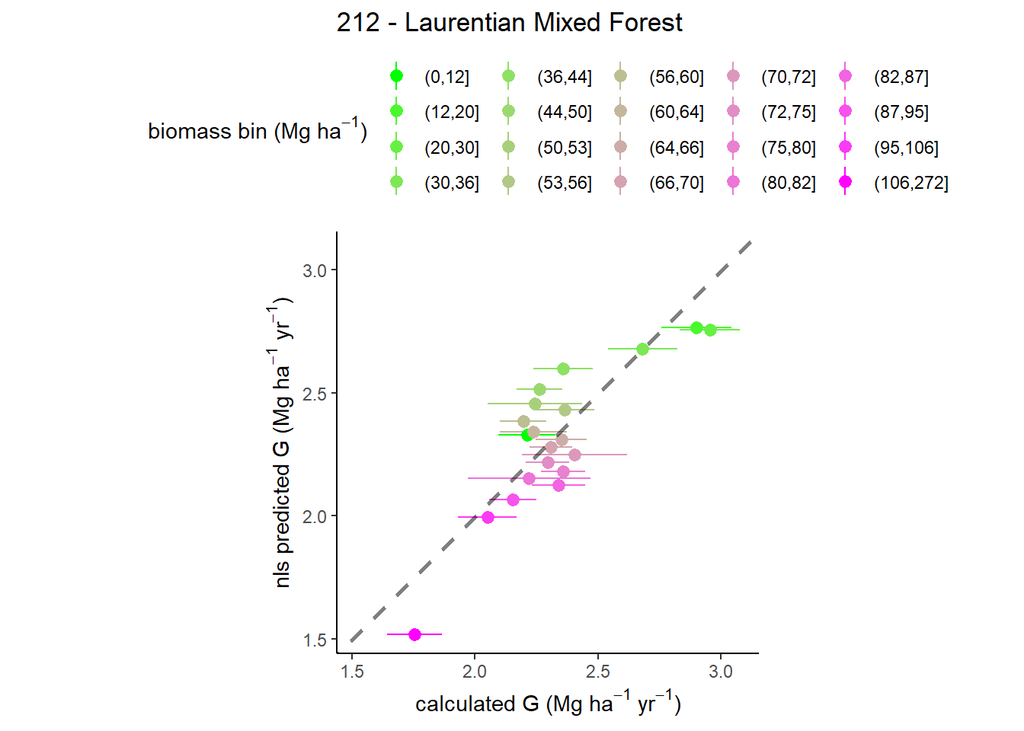

# 221 - Eastern Broadleaf Forest

## model selection 1

```
## Error in numericDeriv(form[[3L]], names(ind), env, central = nDcentral) :
##   Missing value or an infinity produced when evaluating the model
```

```
## Error in numericDeriv(form[[3L]], names(ind), env, central = nDcentral) :
##   Missing value or an infinity produced when evaluating the model
```

```
## Error in numericDeriv(form[[3L]], names(ind), env, central = nDcentral) :
##   Missing value or an infinity produced when evaluating the model
##   model AIC
## 1     1  NA
## 2     2  NA
## 3     3  NA
```

```
## Error in h(simpleError(msg, call)) :
##   error in evaluating the argument 'object' in selecting a method for function 'summary': object 'nls_221.' not found
```

### summary

- simple model: does not fit
- phi model: does not fit
- phi-alpha model: does not fit

## plot residuals

```
## [1] "cannot plot residuals"
```

## predict and plot

```
## [1] "cannot plot data with prediction"
```

## plotting 2

# 222 - Midwest Broadleaf Forest

## model selection 1

```
## Error in numericDeriv(form[[3L]], names(ind), env, central = nDcentral) :
##   Missing value or an infinity produced when evaluating the model
```

```
## Error in numericDeriv(form[[3L]], names(ind), env, central = nDcentral) :
##   Missing value or an infinity produced when evaluating the model
```

```
## Error in numericDeriv(form[[3L]], names(ind), env, central = nDcentral) :
##   Missing value or an infinity produced when evaluating the model
##   model AIC
## 1     1  NA
## 2     2  NA
## 3     3  NA
```

```
## Error in h(simpleError(msg, call)) :
##   error in evaluating the argument 'object' in selecting a method for function 'summary': object 'nls_222.' not found
```

### summary

- simple model: does not fit
- phi model: does not fit
- phi-alpha model: does not fit

## plot residuals

```
## [1] "cannot plot residuals"
```

## predict and plot

```
## [1] "cannot plot data with prediction"
```

## plotting 2

# 223 - Central Interior Broadleaf Forest

## model selection 1

```
## Analysis of Variance Table
##
## Model 1: G_obs_TreeInc_MgHaYr ~ (1 + (MEASTIME_avg - 1990) * ge/100) * (a + b * exp(-((log(STDAGE_t1/c))/d)^2))
## Model 2: G_obs_TreeInc_MgHaYr ~ (1 + (MEASTIME_avg - 1990) * ge/100) * (1 + phi * DeltaPDSI) * (a + b * exp(-((log(STDAGE_t1/c))/d)^2))
## Model 3: G_obs_TreeInc_MgHaYr ~ (1 + (MEASTIME_avg - 1990) * ge/100) * (1 + phi * DeltaPDSI) * (1 - alpha * B_L_prop) * (a + b * exp(-((log(STDAGE_t1/c))/d)^2))
##   Res.Df Res.Sum Sq Df  Sum Sq F value  Pr(>F)
## 1   6035     6472.6
## 2   6034     6467.3  1   5.324  4.9669 0.02587 *
## 3   6031     6321.7  3 145.577 46.2941 < 2e-16 ***
## ---
## Signif. codes:  0 '***' 0.001 '**' 0.01 '*' 0.05 '.' 0.1 ' ' 1
##   model      AIC
## 1     1 24382.01
## 2     2 24379.04
## 3     3 24237.44
```

```
##
## Formula: G_obs_TreeInc_MgHaYr ~ (1 + (MEASTIME_avg - 1990) * ge/100) *
##     (1 + phi * DeltaPDSI) * (1 - alpha * B_L_prop) * (a + b *
##     exp(-((log(STDAGE_t1/c))/d)^2))
##
## Parameters:
##        Estimate Std. Error t value Pr(>|t|)
## ge    -1.015022   0.115192  -8.812  < 2e-16 ***
## phi   -0.016573   0.007291  -2.273 0.023058 *
## alpha  0.565868   0.046393  12.197  < 2e-16 ***
## a      2.851528   0.498390   5.721 1.11e-08 ***
## b      1.770535   0.481159   3.680 0.000236 ***
## c     28.888308   2.292501  12.601  < 2e-16 ***
## d      1.317513   0.324892   4.055 5.07e-05 ***
## ---
## Signif. codes:  0 '***' 0.001 '**' 0.01 '*' 0.05 '.' 0.1 ' ' 1
##
## Residual standard error: 1.024 on 6031 degrees of freedom
##
## Number of iterations to convergence: 8
## Achieved convergence tolerance: 3.53e-06
##   (8 observations deleted due to missingness)
```

### summary

- simple model: fits
- phi model: fits
- phi-alpha model: fits

## plot residuals

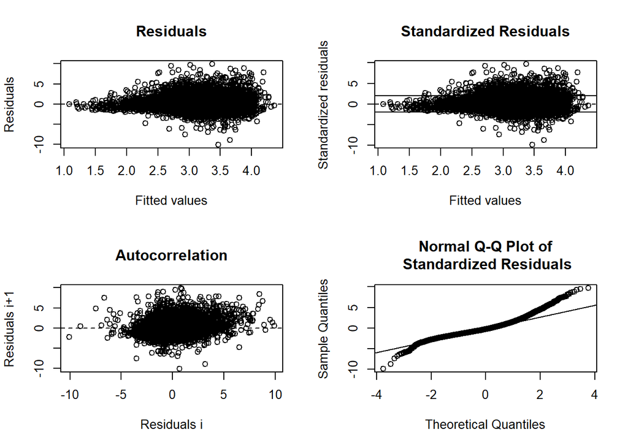

## predict and plot

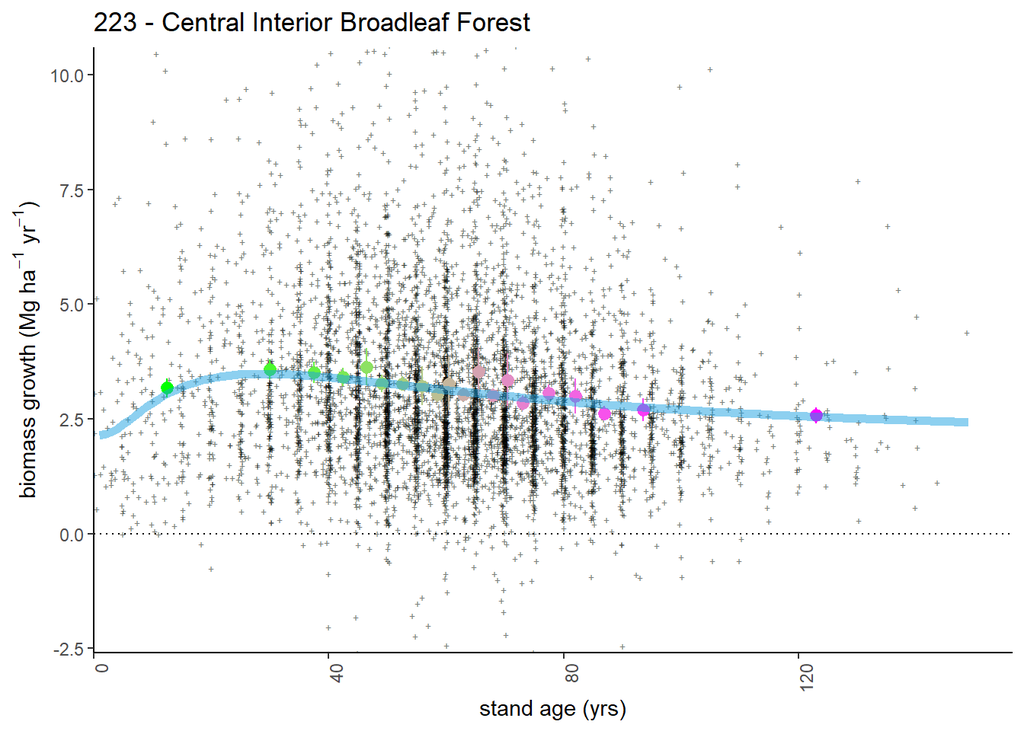

## plotting 2

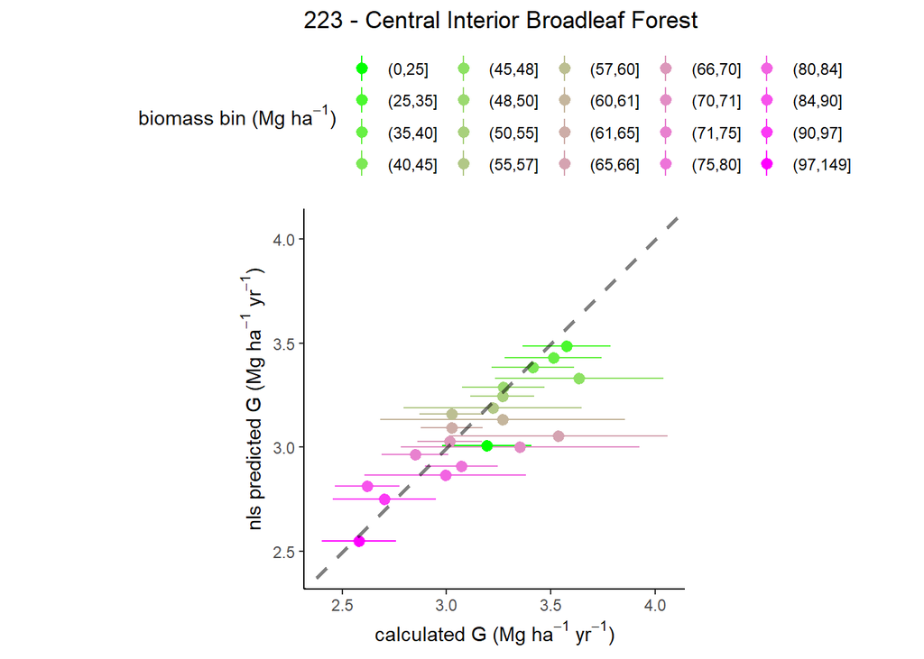

# 231 - Southeastern Mixed Forest

## model selection 1

```
## Analysis of Variance Table
##
## Model 1: G_obs_TreeInc_MgHaYr ~ (1 + (MEASTIME_avg - 1990) * ge/100) * (a + b * exp(-((log(STDAGE_t1/c))/d)^2))
## Model 2: G_obs_TreeInc_MgHaYr ~ (1 + (MEASTIME_avg - 1990) * ge/100) * (1 + phi * DeltaPDSI) * (a + b * exp(-((log(STDAGE_t1/c))/d)^2))
## Model 3: G_obs_TreeInc_MgHaYr ~ (1 + (MEASTIME_avg - 1990) * ge/100) * (1 + phi * DeltaPDSI) * (1 - alpha * B_L_prop) * (a + b * exp(-((log(STDAGE_t1/c))/d)^2))
##   Res.Df Res.Sum Sq Df  Sum Sq  F value Pr(>F)
## 1   7508      12974
## 2   7507      12974  1    0.06   0.0372 0.8471
## 3   7506      11565  1 1408.99 914.4778 <2e-16 ***
## ---
## Signif. codes:  0 '***' 0.001 '**' 0.01 '*' 0.05 '.' 0.1 ' ' 1
##   model      AIC
## 1     1 36817.42
## 2     2 36819.39
## 3     3 35957.66
```

```
##
## Formula: G_obs_TreeInc_MgHaYr ~ (1 + (MEASTIME_avg - 1990) * ge/100) *
##     (1 + phi * DeltaPDSI) * (1 - alpha * B_L_prop) * (a + b *
##     exp(-((log(STDAGE_t1/c))/d)^2))
##
## Parameters:
##        Estimate Std. Error t value Pr(>|t|)
## ge    -0.259497   0.108207  -2.398   0.0165 *
## phi   -0.003945   0.005129  -0.769   0.4418
## alpha  0.865134   0.026078  33.175   <2e-16 ***
## a      3.202037   0.326599   9.804   <2e-16 ***
## b      3.477673   0.306546  11.345   <2e-16 ***
## c     18.706258   0.554203  33.753   <2e-16 ***
## d      1.418369   0.125484  11.303   <2e-16 ***
## ---
## Signif. codes:  0 '***' 0.001 '**' 0.01 '*' 0.05 '.' 0.1 ' ' 1
##
## Residual standard error: 1.241 on 7506 degrees of freedom
##
## Number of iterations to convergence: 11
## Achieved convergence tolerance: 6.205e-06
##   (19 observations deleted due to missingness)
```

### summary

- simple model: fits
- phi model: fits
- phi-alpha model: fits

## plot residuals

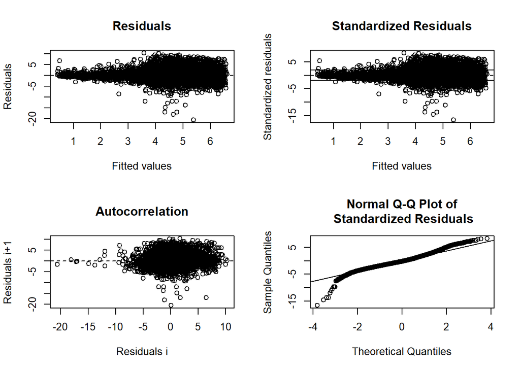

## predict and plot

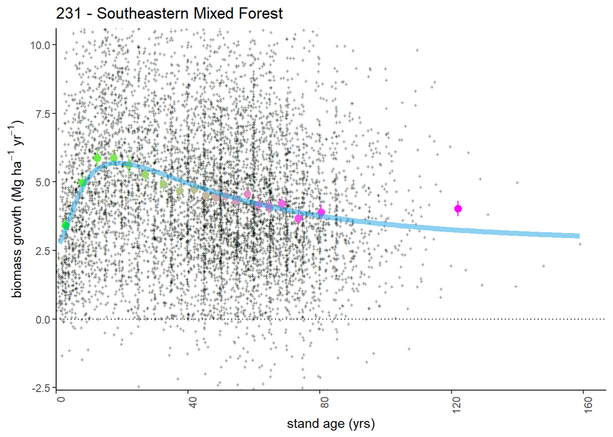

## plotting 2

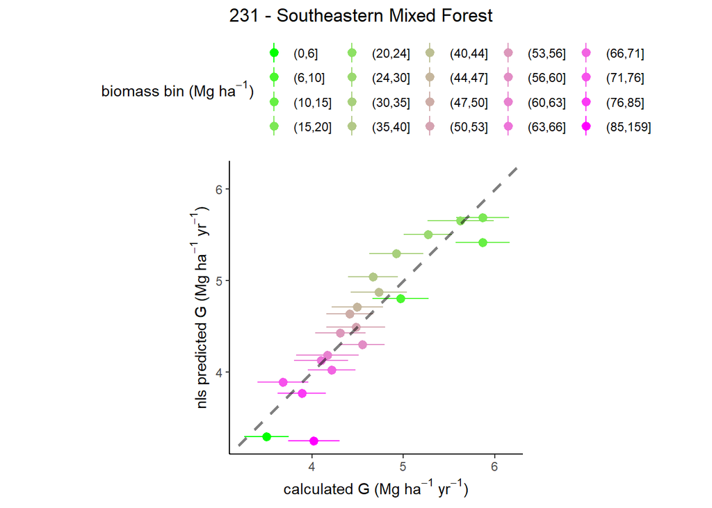

# 232 - Outer Coastal Plain Mixed Forest

## model selection 1

```
## Analysis of Variance Table
##
## Model 1: G_obs_TreeInc_MgHaYr ~ (1 + (MEASTIME_avg - 1990) * ge/100) * (a + b * exp(-((log(STDAGE_t1/c))/d)^2))
## Model 2: G_obs_TreeInc_MgHaYr ~ (1 + (MEASTIME_avg - 1990) * ge/100) * (1 + phi * DeltaPDSI) * (a + b * exp(-((log(STDAGE_t1/c))/d)^2))
## Model 3: G_obs_TreeInc_MgHaYr ~ (1 + (MEASTIME_avg - 1990) * ge/100) * (1 + phi * DeltaPDSI) * (1 - alpha * B_L_prop) * (a + b * exp(-((log(STDAGE_t1/c))/d)^2))
##   Res.Df Res.Sum Sq Df  Sum Sq  F value Pr(>F)
## 1   7527      16090
## 2   7526      16084  1    5.11   2.3905 0.1221
## 3   7525      14759  1 1325.51 675.8205 <2e-16 ***
## ---
## Signif. codes:  0 '***' 0.001 '**' 0.01 '*' 0.05 '.' 0.1 ' ' 1
##   model      AIC
## 1     1 37460.07
## 2     2 37459.68
## 3     3 36813.90
```

```
##
## Formula: G_obs_TreeInc_MgHaYr ~ (1 + (MEASTIME_avg - 1990) * ge/100) *
##     (1 + phi * DeltaPDSI) * (1 - alpha * B_L_prop) * (a + b *
##     exp(-((log(STDAGE_t1/c))/d)^2))
##
## Parameters:
##         Estimate Std. Error t value Pr(>|t|)
## ge    -8.394e-05  1.470e-01  -0.001    1.000
## phi    1.470e-03  5.743e-03   0.256    0.798
## alpha  8.448e-01  2.926e-02  28.878   <2e-16 ***
## a      3.557e+00  1.526e-01  23.311   <2e-16 ***
## b      2.447e+00  1.382e-01  17.709   <2e-16 ***
## c      1.650e+01  5.849e-01  28.213   <2e-16 ***
## d      9.476e-01  7.187e-02  13.185   <2e-16 ***
## ---
## Signif. codes:  0 '***' 0.001 '**' 0.01 '*' 0.05 '.' 0.1 ' ' 1
##
## Residual standard error: 1.4 on 7525 degrees of freedom
##
## Number of iterations to convergence: 9
## Achieved convergence tolerance: 5.39e-06
##   (36 observations deleted due to missingness)
```

### summary

- simple model: fits
- phi model: fits
- phi-alpha model: fits

## plot residuals

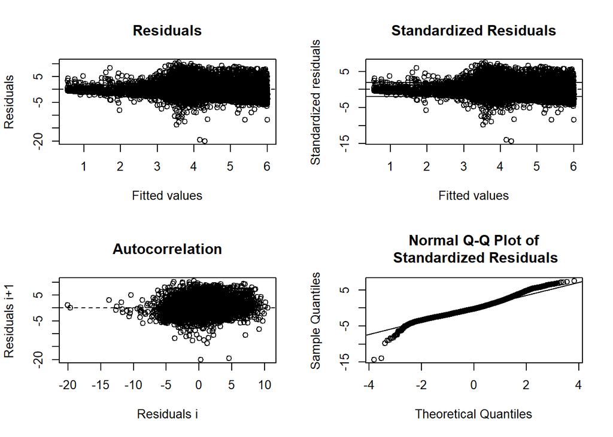

## predict and plot

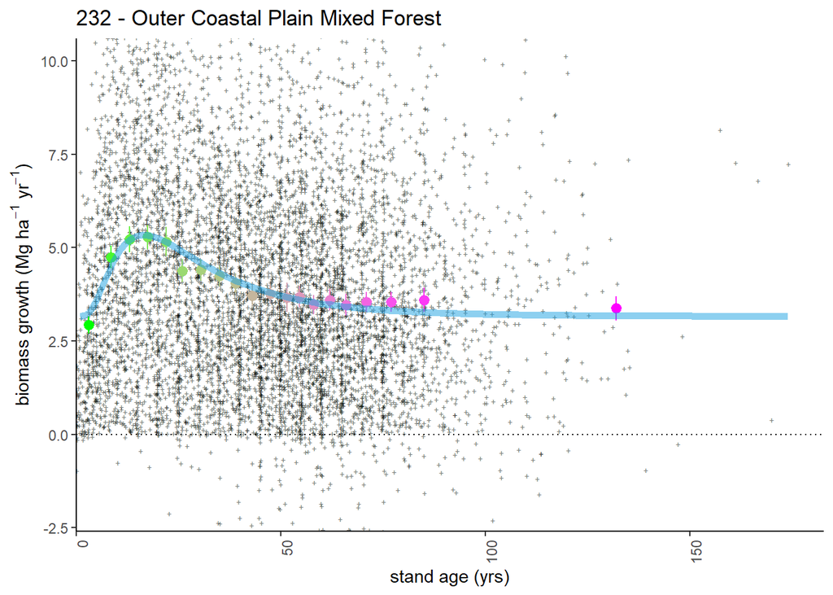

## plotting 2

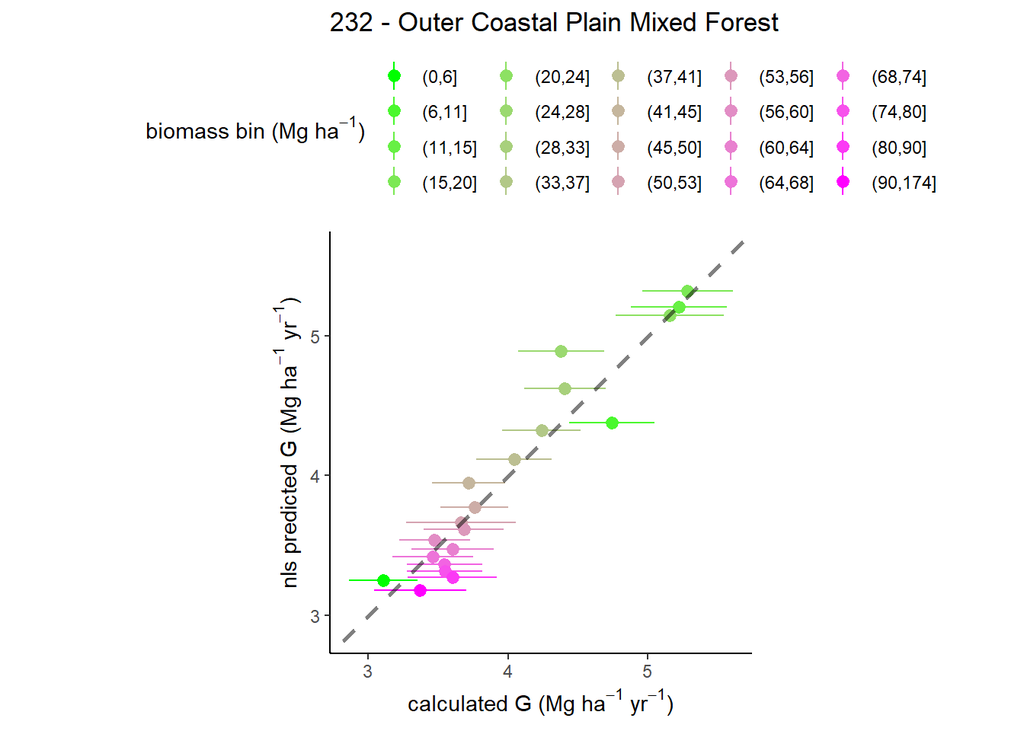

# 234 - Lower Mississippi Riverine Forest

## model selection 1

```
## Analysis of Variance Table
##
## Model 1: G_obs_TreeInc_MgHaYr ~ (1 + (MEASTIME_avg - 1990) * ge/100) * (a + b * exp(-((log(STDAGE_t1/c))/d)^2))
## Model 2: G_obs_TreeInc_MgHaYr ~ (1 + (MEASTIME_avg - 1990) * ge/100) * (1 + phi * DeltaPDSI) * (a + b * exp(-((log(STDAGE_t1/c))/d)^2))
## Model 3: G_obs_TreeInc_MgHaYr ~ (1 + (MEASTIME_avg - 1990) * ge/100) * (1 + phi * DeltaPDSI) * (1 - alpha * B_L_prop) * (a + b * exp(-((log(STDAGE_t1/c))/d)^2))
##   Res.Df Res.Sum Sq Df  Sum Sq F value   Pr(>F)
## 1    778     1720.6
## 2    777     1719.8  1   0.799   0.361   0.5481
## 3    776     1605.0  1 114.864  55.537 2.45e-13 ***
## ---
## Signif. codes:  0 '***' 0.001 '**' 0.01 '*' 0.05 '.' 0.1 ' ' 1
##   model      AIC
## 1     1 3893.542
## 2     2 3895.178
## 3     3 3843.054
```

```
##
## Formula: G_obs_TreeInc_MgHaYr ~ (1 + (MEASTIME_avg - 1990) * ge/100) *
##     (1 + phi * DeltaPDSI) * (1 - alpha * B_L_prop) * (a + b *
##     exp(-((log(STDAGE_t1/c))/d)^2))
##
## Parameters:
##       Estimate Std. Error t value Pr(>|t|)
## ge     0.11940    0.74900   0.159  0.87339
## phi    0.01405    0.02649   0.530  0.59593
## alpha  0.84484    0.10146   8.327 3.73e-16 ***
## a      3.64455    0.69303   5.259 1.88e-07 ***
## b      1.68322    0.53826   3.127  0.00183 **
## c     20.51864    4.05002   5.066 5.07e-07 ***
## d      0.83755    0.38160   2.195  0.02847 *
## ---
## Signif. codes:  0 '***' 0.001 '**' 0.01 '*' 0.05 '.' 0.1 ' ' 1
##
## Residual standard error: 1.438 on 776 degrees of freedom
##
## Number of iterations to convergence: 18
## Achieved convergence tolerance: 5.479e-06
##   (1 observation deleted due to missingness)
```

### summary

[figure not shown]

```
##
## ------
##  Shapiro-Wilk normality test
##
## data:  stdres
## W = 0.97163, p-value = 3.398e-11
##
##
## ------
```

```
##
##  Runs Test
##
## data:  as.factor(run)
## Standard Normal = -3.867, p-value = 0.0001102
## alternative hypothesis: two.sided
```

## predict and plot

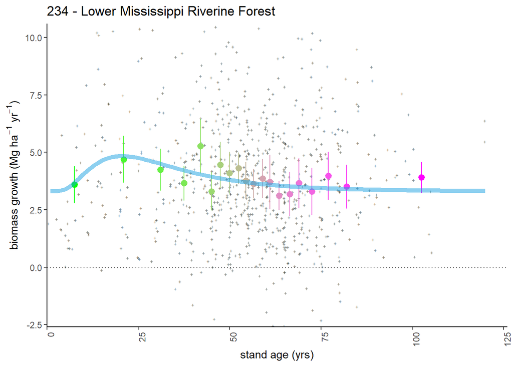

## plotting 2

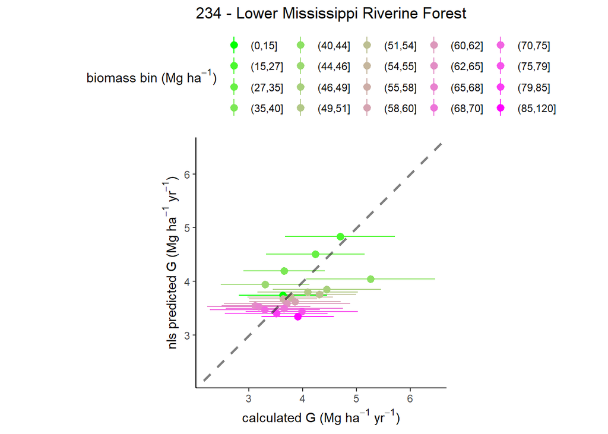

# 242 - Pacific Lowland Mixed Forest

## model selection 1

[output not shown]

```
## Error in h(simpleError(msg, call)) :
##   error in evaluating the argument 'object' in selecting a method for function 'summary': object 'nls_242.' not found
```

### summary

- simple model: does not fit
- phi model: does not fit
- phi-alpha model: does not fit

## plot residuals

```
## [1] "cannot plot residuals"
```

## predict and plot

```
## [1] "cannot plot data with prediction"
```

## plotting 2

# 251 - Prairie Parkland (Temperate)

## model selection 1

[output not shown]

```
## Error in h(simpleError(msg, call)) :
##   error in evaluating the argument 'object' in selecting a method for function 'summary': object 'nls_251.' not found
```

### summary

- simple model: does not fit
- phi model: does not fit
- phi-alpha model: does not fit

## plot residuals

```
## [1] "cannot plot residuals"
```

## predict and plot

```
## [1] "cannot plot data with prediction"
```

## plotting 2

# 255 - Prairie Parkland (Subtropical)

## model selection 1

[output not shown]

```
## Error in h(simpleError(msg, call)) :
##   error in evaluating the argument 'object' in selecting a method for function 'summary': object 'nls_255.' not found
```

### summary

- simple model: does not fit
- phi model: does not fit
- phi-alpha model: does not fit

## plot residuals

```
## [1] "cannot plot residuals"
```

## predict and plot

```
## [1] "cannot plot data with prediction"
```

## plotting 2

# 261 - California Coastal Chaparral Forest and Shrub

## model selection 1

### summary

- simple model: does not fit
- phi model: does not fit
- phi-alpha model: does not fit

## plot residuals

```
## [1] "cannot plot residuals"
```

## predict and plot

```
## [1] "cannot plot data with prediction"
```

## plotting 2

# 262 - California Dry Steppe

## model selection 1

### summary

- simple model: does not fit
- phi model: does not fit
- phi-alpha model: does not fit

## plot residuals

```
## [1] "cannot plot residuals"
```

## predict and plot

```
## [1] "cannot plot data with prediction"
```

## plotting 2

# 263 - California Coastal Steppe - Mixed Forest and Redwood Forest

## model selection 1

[output not shown]

```
## Error in h(simpleError(msg, call)) :
##   error in evaluating the argument 'object' in selecting a method for function 'summary': object 'nls_263.' not found
```

### summary

- simple model: does not fit
- phi model: does not fit
- phi-alpha model: does not fit

## plot residuals

```
## [1] "cannot plot residuals"
```

## predict and plot

```
## [1] "cannot plot data with prediction"
```

## plotting 2

# 313 - Colorado Plateau Semi-Desert

## model selection 1

[output not shown]

```
## Error in h(simpleError(msg, call)) :
##   error in evaluating the argument 'object' in selecting a method for function 'summary': object 'nls_313.' not found
```

### summary

- simple model: does not fit
- phi model: does not fit
- phi-alpha model: does not fit

## plot residuals

```
## [1] "cannot plot residuals"
```

## predict and plot

```
## [1] "cannot plot data with prediction"
```

## plotting 2

# 315 - Southwest Plateau and Plains Dry Steppe and Shrub

## model selection 1

[output not shown]

### summary

- simple model: does not fit
- phi model: does not fit
- phi-alpha model: does not fit

## plot residuals

```
## [1] "cannot plot residuals"
```

## predict and plot

```
## [1] "cannot plot data with prediction"
```

## plotting 2

# 321 - Chihuahuan Semi-Desert

## model selection 1

### summary

- simple model: does not fit
- phi model: does not fit
- phi-alpha model: does not fit

## plot residuals

```
## [1] "cannot plot residuals"
```

## predict and plot

```
## [1] "cannot plot data with prediction"
```

## plotting 2

# 322 - American Semidesert and Desert

## model selection 1

[output not shown]

```
## Error in h(simpleError(msg, call)) :
##   error in evaluating the argument 'object' in selecting a method for function 'summary': object 'nls_322.' not found
```

### summary

- simple model: does not fit
- phi model: does not fit
- phi-alpha model: does not fit

## plot residuals

```
## [1] "cannot plot residuals"
```

## predict and plot

```
## [1] "cannot plot data with prediction"
```

## plotting 2

# 331 - Great Plains/Palouse Dry Steppe

## model selection 1

### summary

- simple model: does not fit
- phi model: does not fit
- phi-alpha model: does not fit

## plot residuals

```
## [1] "cannot plot residuals"
```

## predict and plot

```
## [1] "cannot plot data with prediction"
```

## plotting 2

# 332 - Great Plains Steppe

## model selection 1

### summary

- simple model: does not fit
- phi model: does not fit
- phi-alpha model: does not fit

## plot residuals

```
## [1] "cannot plot residuals"
```

## predict and plot

```
## [1] "cannot plot data with prediction"
```

## plotting 2

# 341 - Intermountain Semi-desert & Desert

## model selection 1

### summary

- simple model: does not fit
- phi model: does not fit
- phi-alpha model: does not fit

## plot residuals

```
## [1] "cannot plot residuals"
```

## predict and plot

```
## [1] "cannot plot data with prediction"
```

## plotting 2

# 342 - Intermountain Semi-Desert

## model selection 1

### summary

- simple model: does not fit
- phi model: does not fit
- phi-alpha model: does not fit

## plot residuals

```
## [1] "cannot plot residuals"
```

## predict and plot

```
## [1] "cannot plot data with prediction"
```

## plotting 2

# 411 - Everglades

## model selection 1

### summary

- simple model: does not fit
- phi model: does not fit
- phi-alpha model: does not fit

## plot residuals

```
## [1] "cannot plot residuals"
```

## predict and plot

```
## [1] "cannot plot data with prediction"
```

## plotting 2

# M211 - Adirondack-New England Mixed forest - Coniferous Forest - Alpine Meadow

## model selection 1

```
## Analysis of Variance Table
##
## Model 1: G_obs_TreeInc_MgHaYr ~ (1 + (MEASTIME_avg - 1990) * ge/100) * (a + b * exp(-((log(STDAGE_t1/c))/d)^2))
## Model 2: G_obs_TreeInc_MgHaYr ~ (1 + (MEASTIME_avg - 1990) * ge/100) * (1 + phi * DeltaPDSI) * (a + b * exp(-((log(STDAGE_t1/c))/d)^2))
## Model 3: G_obs_TreeInc_MgHaYr ~ (1 + (MEASTIME_avg - 1990) * ge/100) * (1 + phi * DeltaPDSI) * (1 - alpha * B_L_prop) * (a + b * exp(-((log(STDAGE_t1/c))/d)^2))
##   Res.Df Res.Sum Sq Df  Sum Sq F value    Pr(>F)
## 1   5062     3422.7
## 2   5061     3404.5  1  18.235  27.107 2.001e-07 ***
## 3   5060     3193.2  1 211.252 334.752 < 2.2e-16 ***
## ---
## Signif. codes:  0 '***' 0.001 '**' 0.01 '*' 0.05 '.' 0.1 ' ' 1
##   model      AIC
## 1     1 18086.97
## 2     2 18061.91
## 3     3 17739.31
```

```
##
## Formula: G_obs_TreeInc_MgHaYr ~ (1 + (MEASTIME_avg - 1990) * ge/100) *
##     (1 + phi * DeltaPDSI) * (1 - alpha * B_L_prop) * (a + b *
##     exp(-((log(STDAGE_t1/c))/d)^2))
##
## Parameters:
##        Estimate Std. Error t value Pr(>|t|)
## ge     0.982253   0.213940   4.591 4.51e-06 ***
## phi    0.017564   0.004628   3.795 0.000149 ***
## alpha  0.626347   0.031921  19.622  < 2e-16 ***
## a      2.337174   0.155159  15.063  < 2e-16 ***
## b      0.723209   0.112624   6.421 1.47e-10 ***
## c     28.936638   2.146717  13.479  < 2e-16 ***
## d      0.998175   0.206039   4.845 1.31e-06 ***
## ---
## Signif. codes:  0 '***' 0.001 '**' 0.01 '*' 0.05 '.' 0.1 ' ' 1
##
## Residual standard error: 0.7944 on 5060 degrees of freedom
##
## Number of iterations to convergence: 8
## Achieved convergence tolerance: 5.873e-06
##   (1 observation deleted due to missingness)
```

### summary

- simple model: fits
- phi model: fits
- phi-alpha model: fits

## plot residuals

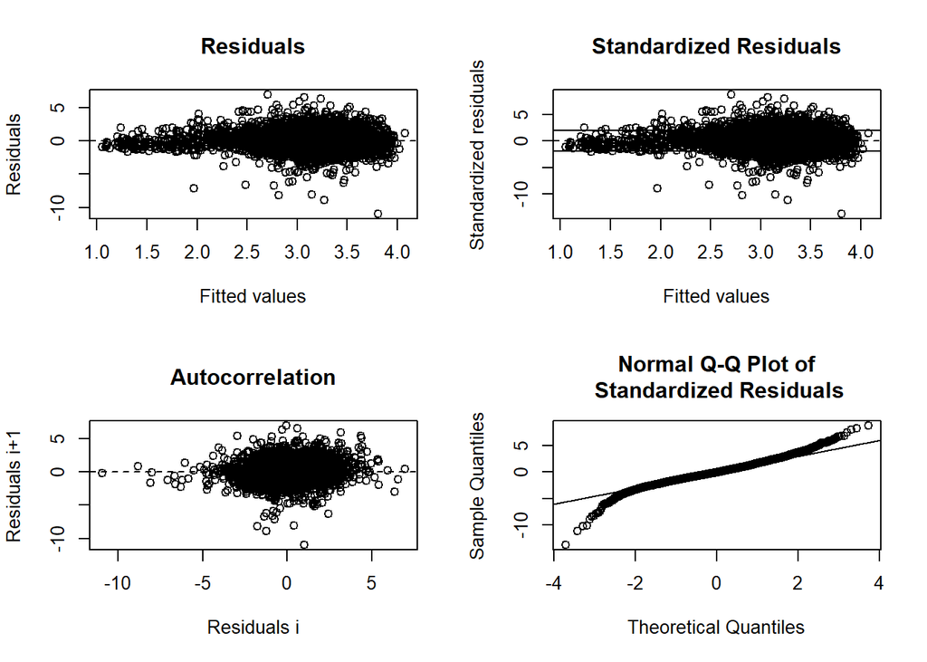

## predict and plot

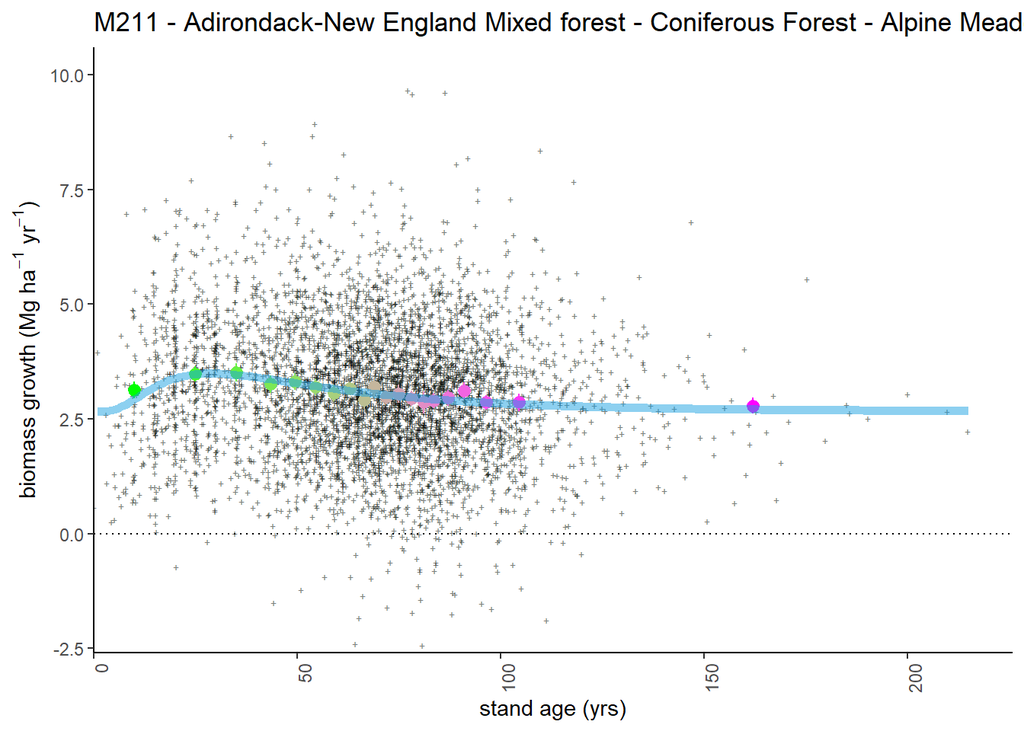